```python
# Project 1 - Test a Perceptual Phenomenon
'''
Created by Laura Uzcategui
Date : 9 Aug 2015
'''
```

```
'\nCreated by Laura Uzcategui \nDate : 9 Aug 2015 \n'
```

# The Stroop Effect

In a Stroop task, participants are presented with a list of words, with each word displayed in a color of ink. The participant’s task is to say out loud the color of the ink in which the word is printed. The task has two conditions: a congruent words condition, and an incongruent words condition. In the congruent words condition, the words being displayed are color words whose names match the colors in which they are printed: for example RED, BLUE. In the incongruent words condition, the words displayed are color words whose names do not match the colors in which they are printed: for example PURPLE, ORANGE. In each case, we measure the time it takes to name the ink colors in equally-sized lists. Each participant will go through and record a time from each condition.

### 1. What is our independent variable? What is our dependent variable?

- Independent Variable: In this case the independent variable would be the treatments applied to the participants. The treatments are: Congruent Words and Incongruent Words Condition.
- Dependent Variable: the time that it takes to name the ink-colors for every treatment.

### 2. What is an appropriate set of hypotheses for this task? What kind of statistical test do you expect to perform? Justify your choices.

The appropiate hypotheses for this task will be the following:

- H0 ( Null hypotheses) : $\mu C = \mu I $ The mean population from the Congruent Words are not different from the Mean the Incongruent Words
- H1 ( Alternative hypotheses) : $\mu C - \mu I < 0 $ The difference of Congruent and Incongruent is less than zero ( One Tail Test)

```python
# making available graphs inline
%pylab inline
# importing pandas for manipulation of data
import pandas as pd
# importing scipy and matplotlib for creating and plotting the distributions
import numpy as np
import matplotlib.pyplot as plt
import matplotlib.mlab as mlab
```

```python
# Loading the path of our data sample
path = './stroopdata.csv'

# Reading our data sample
df = pd.read_csv(path)
```

```python
# Printing our data
df
```

|  | Congruent (c) | Incongruent (i) |
| --- | --- | --- |
| 0 | 12.079 | 19.278 |
| 1 | 16.791 | 18.741 |
| 2 | 9.564 | 21.214 |
| 3 | 8.630 | 15.687 |
| 4 | 14.669 | 22.803 |
| 5 | 12.238 | 20.878 |
| 6 | 14.692 | 24.572 |
| 7 | 8.987 | 17.394 |
| 8 | 9.401 | 20.762 |
| 9 | 14.480 | 26.282 |
| 10 | 22.328 | 24.524 |
| 11 | 15.298 | 18.644 |
| 12 | 15.073 | 17.510 |
| 13 | 16.929 | 20.330 |
| 14 | 18.200 | 35.255 |
| 15 | 12.130 | 22.158 |
| 16 | 18.495 | 25.139 |
| 17 | 10.639 | 20.429 |
| 18 | 11.344 | 17.425 |
| 19 | 12.369 | 34.288 |
| 20 | 12.944 | 23.894 |
| 21 | 14.233 | 17.960 |
| 22 | 19.710 | 22.058 |
| 23 | 16.004 | 21.157 |

### Descriptive Statistics

In the next section you will observe some Descriptive Statistics for each sample.

In order to be clear in the rest of the project, please notice the following notations:

- $\overline{x_c} \Rightarrow$ Mean of c ( Congruent Samples ) perfomance
- $\overline{x_i} \Rightarrow$ Mean of i ( Incongruent Samples ) perfomance

### Value of $\overline{x_c}$

```python
#Calculating the Mean of Congruent Samples
mean_c = round(df['Congruent (c)'].mean(),2)
mean_c
```

```
14.05
```

### Value of $\sigma {c}$

```python
#Calculating the standard deviation of Congruent Samples
std_c = round(df['Congruent (c)'].std(),2)
std_c
```

```
3.56
```

### Value of $\overline{x_i}$

```python
#Calculating the Mean of Incongruent Samples
mean_i = round(df['Incongruent (i)'].mean(),2)
mean_i
```

```
22.02
```

### Value of $\sigma {i}$

```python
#Calculating the standard deviation of Incongruent Samples
std_i = round(df['Incongruent (i)'].std(),2)
std_i
```

```
4.8
```

```python
# Calculating Point Estimate
diff_samples = df['Congruent (c)'] - df['Incongruent (i)']
point_e = round(diff_samples.mean(),2)
```

```python
point_e
```

```
-7.96
```

```python
#Calculating Square Difference
sq_diff = (diff_samples - point_e ) ** 2
```

```python
#Calculating some measures of variability
variance = round( sq_diff.sum() / (sq_diff.count() - 1 ) ,2)
```

### Variance

```python
variance
```

```
23.67
```

### Standard Deviation ( S )

```python
#Calculating the sample standard deviation of the differences
std_s = round(diff_samples.std(),2)
```

```python
std_s
```

```
4.86
```

### Visualizations of sample data and the difference of samples

As you can observed in the following Normal Distribution plots for Congruents and Incongruents samples, the plot for Congruent samples is more skinny, in the other hand the plot for Incongruent sample looks like is more spread out,as a conclusion we can confirm that the smaller standard deviation the skinnier the sample distribution.

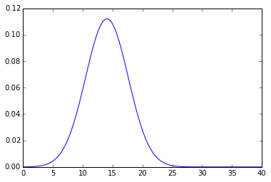

```python
# Plotting Normal Distribution for Congruent Words

bin_c = np.linspace(0,40,100)
plt.plot(bin_c,mlab.normpdf(bin_c,mean_c,std_c))
```

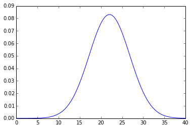

```python
# Plotting Normal Distribution for Incongruent Words

bin_i = np.linspace(0,40,100)
plt.plot(bin_i,mlab.normpdf(bin_i,mean_i,std_i))
```

### $\alpha$ Level - Confidence Level

Our $\alpha$ level will be : 0.05 (5%) - One tail T-test

#### Degrees of Freedom

df = n - 1, where n = 24 df = 23

### T Critical Value

t(23) = -1.714

```python
#Calculating t-statistic value

t_stat = round(point_e / (std_s / sqrt(sq_diff.count())),2)
t_stat
```

```
-8.02
```

### Results of the study

Based on the calculation for T-statistic.

##### if we express this as per calculated by hand would be :

t_statistic < t_critical value so that : -8.02 < -1.714

We reject the null and said that the difference is statistically significant since falls in the critical region. Based on results of the test, the conclusion will be that it match with the alternative hypothesis proposed above. c Particularly and after some research, it is believed that there are interference between the fact that the colors are not the same as the word and this could cause some kind of distraction in the subject who is taking the test. This test can ben done as well with another kind of interference such as figures, or putting the word in reverse and so on, also would be interesting to compare this performance between subjects at different ages and the cognitive and memory process.

### References.

[1] MacLeod CM. (1991) Half a century of research on the Stroop effect: an integrative review.

[2] MacLeod CM and McDonald P (2000) Interdimensional interference in the Stroop effect: uncovering the cognitive and neural anatomy of attention.

[3] Quick calcs (http://www.graphpad.com/quickcalcs/)